# Chicken in Apple Project

Zoe Heuschkel, Lars Caspersen and Miracle Obeng

15/08/2021

# 1 Introduction

Chicken in apple plantation is an agroforestry practice. The integration of poultry with crops and/or trees production has been identified as a sustainable way to increase the productivity of land and to provide a number of ecosystem services and environmental benefits compared to disaggregated agricultural and woodland systems (Smith, Pearce, and Wolfe 2013). Literature shows that the outdoor range is in general better used when they had more trees or hedges and the number of birds ranging outside is correlated with the percentage tree cover on the range (Hemery 2005). The main benefits to chickens arising from the use of trees are potential changes to the microclimate and animal welfare (Berg 2002). Chickens kept outside exhibit signs of reduced stress, as evidenced by less pecking damage (Monique Bestman and Bikker-Ouwejan 2020). Trees can provide a welfare benefit depending on the sizes and numbers of trees and poultry (Yates et al. 2007). They offer an environment closer to that of the jungle fowl from which chicken breeds are descended and the opportunity to express natural behavior (Berg 2002). In particular, trees provide shade from the sun, dry areas for dust bathing, shelter from aerial predators and from ground predators approaching from the side (MWP Bestman and Wagenaar 2003). In existing ‘free-range’ egg or meat systems poultry are reluctant to range and only 14% of birds range at one time (Dawkins et al. 2003).  
The trees can also provide a means of escaping from aggressive behaviour as well as the reduction of visual stimuli that provoke aggression. An increase in the environmental diversity or behavioral enrichment can also increase welfare standards for animals as it permits the expression of frustrated behavioral motivations (Broom 1988). Organic and free-range poultry have, besides having access to a hen house, access to an outdoor run. In this respect, it is well known that poultry are more inclined to use the range when it is enriched with trees, and that in turn feather picking is reduced when more hens use the range (MWP Bestman and Wagenaar 2003). Thus the establishment of trees in the outdoor run is considered to improve hen welfare.  
Another associated benefit of the system is the provision of valuable revenue streams from commercial tress (apples) and the sales of chicken products (eggs) (Yates et al. 2007). Markets for products that have been produced in systems that offer welfare and or environmental benefits and that are perceived as more ‘natural,’ have grown substantially in recent years in many countries, particularly in Western Europe. In the UK, freerange eggs (i.e. produced in a system where birds have access to pasture) account for 27% of all eggs produced (DEFRA 2005a) and are retailed at a premium of 22% and 147% compared to conventional ‘barn’ and ‘caged’ produced eggs respectively (British Egg Information Service pers. comm. 2002) (Yates et al. 2007).  
Brownlow, Carruthers, and Dorward (2000) give the following specific reasons for considering such systems: i). The significant growth in outdoor poultry enterprises (such as free-range egg production) leading to increased demands on land resources. ii). Recognition of the use of tree cover to improve the welfare conditions of outdoor poultry. iii).The potential for exploiting markets for ‘forest-reared’ poultry. iv). Increasing demands on forest managers to find new uses for forest resources and alternative methods for the silvicultural treatment of tree crops. Additional benefits of the system is that, where there is more tree cover, fewer water birds will enter. This is critical as water birds can transmit avian influenza virus (Monique Bestman et al. 2018).

The paragraphs above established, that it is quite beneficial for the chicken to be kept in orchards. However, it is unclear if the orchard benefit in a similar way from the presence of the fowl. It is hypothesized that chicken could reduce the presence of harmful insects like the apple sawfly (*Holocampa testudinea*) or the pear midge (*Contarinia pyrivora*) (Pedersen et al. 2004). Furthermore, also the incidence of fungal diseases like apple scab caused by the fungus (*Venturia inaequalis*) is suspected to be lower in apple-chicken systems because the chicken feed on the fallen apples leaves which are an important off-season host for the fungus (Timmermans 2016). Further benefits could lie in reduced weed control and grass mowing costs because the chicken feed on the weeds and the grass while roaming the orchard. Additionally, the presence of voles might be reduced in a chicken-apple due to the foraging behavior of the chicken.  
While all these aspects hold potential for additional benefit for an apple farmer introducing chicken to the system, the quantification of these apple-chicken synergies is challenging and subject to large uncertainty. Studies dedicated to the chicken-apple synergies (Pedersen et al. 2004; Timmermans 2016) are limited and suffer for methodological shortcomings like having investigated only few years or farms for comparison. Also, translating a mere presence of chicken on e.g. the presence of apple sawfly does not necessarily translate in an effect of higher yields (Pedersen et al. 2004) or reduced control costs. Another aspect to consider is the gradual decrease of the chicken impact on the orchard with increasing distance to the chicken coop (Timmermans 2016). Weed control is very effective when the chicken are close to the plantation (48m). However, this is reduce when the coop is far away (198m) from the plantation (Timmermans 2016).  
Aside from synergistic effects of combining apple and chicken systems, there are also negative consequences possible (trade-offs). For instance trees, especially when they are young, are suspected to be dameged by the chicken when close to the coop due to intensive foraging which might damage the rootstock (Timmermans 2016). If not drained properly, also the soil around the coop can become too most making drainage necessary (MWP Bestman, Hermansen, and Burgess 2017). Fruthermore, the presence of chicken could put a further burden on the apple orchard management, because the fencing might be blocking the path and spraying while the chicken are present in the orchard is not allowed.

As can be seen, deciding whether to include chicken to an already existing apple orchard is less trivial than one might expect. The benefits and cost of the decision are beyond the immediate revenues and cost associate to the additional chicken, due to possible synergies and trade-offs. Furthermore, the economic assessments available to practitioners rely on single values completely ignoring the uncertainty in their estimations (for exanple in Alpers (2015) p. 16). A framework to overcome such limitations is the Decision Analysis (Luedeling and Shepherd 2016). This method is lately used to support the decision with the agricultural sector, like changing an arable maize system to agroforestry in Nothern Vietnam (Do, Luedeling, and Whitney 2020), the investment in hail nets for cherry trees in Central Chile (Rojas et al. 2021) or even to analyse the impact of agricultural policies on household nutrition in Uganda (Whitney et al. 2018). The Decision Analysis framework offers many advantages. Its probabilistic modeling considers the uncertainty of variables value. Furthermore, it allows to make use of expert knowledge instead of relying solely on the outcomes of expensive and methodologically challenged (field) experiments. Thanks to the `decisioSupport` package (Luedeling et al. 2021) in R, making use of the aforementioned methodological framework is feasible and will be thus be used in this project.

# 2 Decision

Should a commercial conventional apple farmer, located in North Rhine-Westphalia, Germany, include free-ranging egg-laying chicken to his orchard?

# 3 Decision Maker

Farmers with already established, conventional commercial apple farmer in North Rhine-Westphalia, Germany. Farmers are key decision makers because of the Net Present Value (NPV) calculation in the model. This is a variable which is more important to the producers (farmer).

# 4 Interview with Farmers

Pursuant to our project, we reached out to conventional apple and chicken farmers on our decision to include poultry in apple orchards. We explained to them a particular advantage of our decision model as it allows expert knowledge to be included in the calculations and uncertainties (such as pest suppression) to be explicitly based on expert assessments instead of lengthy measurements.

Court Farms Chickens in United Kingdom (UK), a farm currently keeping all their birds in apple, cherry and plum orchards rather than in fields. In an interview with the Farm Manager, he mentioned some of the few reasons they are actively practicing the system. According him, the land is cheaper, the trees provide natural cover and shelter which enables the birds display much more natural behavior and are happier. The roots in the ground provide stability and drainage in the winter and which helps prevent the land turning into a mud bath is an environmental benefit that the system provides, he said.  
On the other hand, he expressed his displeasure in the system, he mentioned that, it difficult to install fencing because of the trees and roots. Again trunks of trees needs to be protected from hens. He iterated that fallen fruit is fine to be eaten by the birds but they have to monitor the amount as too much will make them ill so it has to be manually collected each morning and also becomes difficult to harvest the trees with the birds, coops and fencing now in the way. He further mentioned that, plum stones when eaten by turkeys and chicken can induce cyanide poisoning.

The Human Resource (HR) and Recruitment Director of AC Gotham and Son farms in the UK pointed out that, chicken in apple orchards is a system that they are unfortunately, not willing to consider. According to him, there are the practical implications of protecting the chickens from natural predators such as foxes, however, the consideration of what they would do with all the eggs laid across the 3,000 acres of orchards they have.

# 5 Input Table

# 6 Conceptual Model

The conceptual model of the decision to include chicken into the apple orchard consists out of two main parts (Figure 1). The first covers the direct costs and benefits of the to be included chicken. Costs consist out of the investment costs and the running costs. Under investment costs falls mainly the infrastructure necessary to keep the chicken which are a mobile chicken house and fencing. Running costs are the recurring cost items of keeping chicken. These are namely the egg-laying hens bought, fodder and bedding, costs of the veterinarian, energy and water, maintenance cost of the housing, costs associated to market the chicken products (like finding a seller for the chicken produce), costs of the animal insurance and additional labor costs. These cost items were expressed on basis per chicken kept, so that they are scaleable when applying the model to another scenario of orchard or flock size. Furthermore, we included the risk of avian influenza which can either occur in the neighborhood of the establishment or within the chicken flock. Either way, it mainly increases the running costs, as there are certain protocols and procedures to follow in these cases putting extra burden on the management. In the neighborhood case, the farmer has to keep the chicken strictly indoor and test the chicken regularly. In case of avian influenza the whole flock needs to be slaughtered. Since the insurance covers for the loss of the chicken value and the forgone revenue by the chicken products, we assumed that avian influenza does not affect the revenue part of our model. Direct benefits of the chicken include the laid eggs throughout the year and the ‘old’ chicken at the end of the year sold for meat. These are modified by the prices for the produce, the period length of egg-laying and the egg-output per chicken. Furthermore the share of marketable eggs and the ‘survival’ rate of the chicken affect the benefits. The total direct revenue of keeping chicken in the orchard are calculated by subtracting the costs from the benefits.

The other component of the model consists out of the apple orchard. In our project we decided to include all aspects of the apple orchard even if not amended by the presence of chicken. So similar to the chicken part, it consists out of the costs and benefits of growing apple, with the difference that the orchard is already established and thus there are no initial investments. Benefits come mainly from the apple harvested and sold, which are modified by the apple price and yield. Costs were differentiated between items affected by the chicken and chicken-independent ones. Chicken independent running costs included pruning, fertilization and apple harvest. Chicken modified costs include the mowing of the lawn in between the apple rows, the weeding within the bare soil strip of the apple rows as well as costs for control of voles, fungal diseases like apple scab and harmful insects like the apple sawfly.

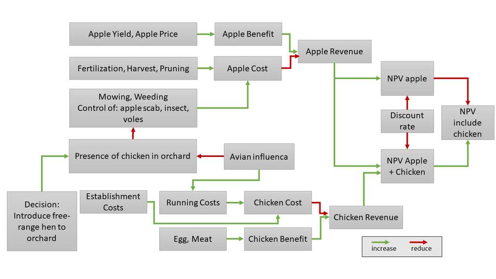

Figure 6.1: Figure 1: Graphical model of the appl-chicken system. Red arrows denote negative influences and green arrows positive influences

# 7 Coded model

The model is structured similar to the graphical model. At first the cost and then the benefits of the apple subsystem are calculated, followed by the expenses and income of the chicken subsystem. In both subsystems the cost items are expressed per tree / chicken. Especially variables covering prices or work time were varied within the years using `vv()`. In case of apple scab, harmful insect control and voles a chance for an especially bad year was included using `chance_event()` and a variable stating by how many percent the control costs increase in case of the event. Furthermore, in case of the event, a yield reduction of the apple trees is assumed. We assumed that these events happen independent from each other, so it is also possible that in an especially unfortunate year all these events happen at the same time. The yield reduction factor is in these cases ‘collected’ and then applied to reduce the regular yield. Impact of voles on trees were handle differently than apple scab and insect. We assumed that voles kill individual tree by damaging the rootstock. So in case of voles, we assumed that a certain share of the trees die in event of a ‘bad’ vole year. Furthermore, we assumed that newly planted trees for the first three years do not yield any apples and for the following three years only a lower amount of apples than fully mature apple trees. Yield of young and mature trees were calculated independent from each other. To keep track of the three tree populations (no yield, reduced yield and full yield) a function was written (`calc_tree_population()`). It takes the vector of the `chance_event()` for voles as an input and returns the quantity of mature and young trees as output. In case of apple scab, insect, voles, weeding and mowing, the presence of chicken in the orchard was assumed to be beneficial. To keep the calculations simple, we assumed that the costs of control were reduced but the yield was left unaltered. After havin calculated the costs, the benefits of the apple subsystem was calculated by multiplying the tree populations with yield per tree and apple price.

In the second step costs and benefits of the chicken subsystem were calculated. Most noteworthy is again a `chance_event()` for the two cases of avian influenza: either in neighborhood or within the flock. Since the function was applied for both events independently, there was a small chance that in one year both yield a positive value. In that case the more severe case outweighs and the malus for management cost is only increased by the factor of the flock scenario. In either case the synergistic effect of chicken and apple on the control cost were set to zero for the influenza years because the chickens were kept indoors / were slaughtered. Additional to the threat of avian influenza, we also had a general threat that the chicken might not survive the year in our model, expressed as `survival_rate`. However, in the case of ‘regular’ death it is assumed that the chicken die right away at the first day, do not produce any eggs or consume any fodder or dirty any bedding. Furthermore, it is assumed that the farmer buys chicken at a yearly basis, even though the high productive egg-laying period is somewhat shorter.

At the end of the model, revenues of the apple subsystem are subtracted from the combined system to model the additional money earned / lost by the decision to include chicken to the apple orchard.

# 8 Model Outcome

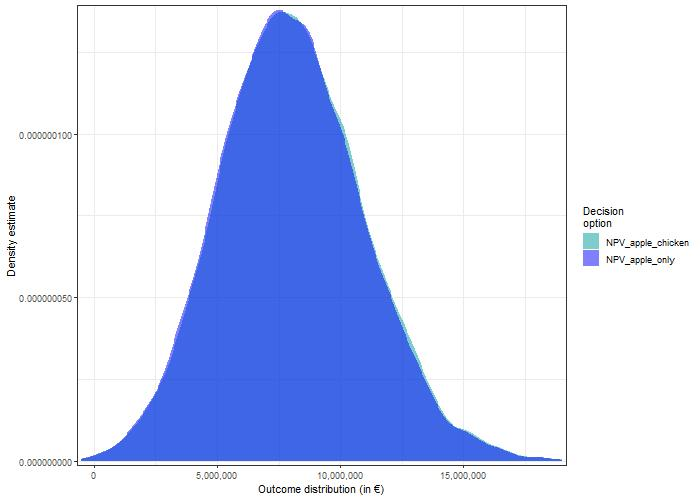

Figure 8.1: Figure 2: Outcome of the Monte-Carlo Simulation (n = 10,000) showing in Net Present Value of pure apple system (NPV_apple_only) and apple-chicken combined system (NPV_apple_chicken)

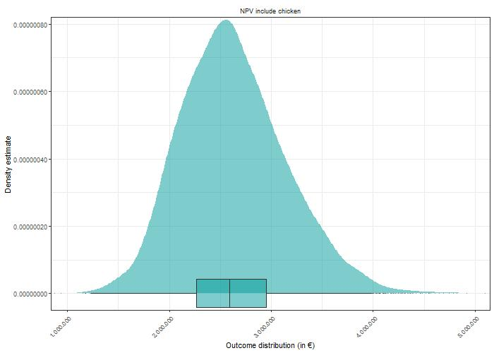

Figure 8.2: Figure 3: Outcome of Monte-Carlo-Simulation (n = 10,000) showing the decision to include chicken to apple system (NPV_apple_chicken - NPV_apple_only)

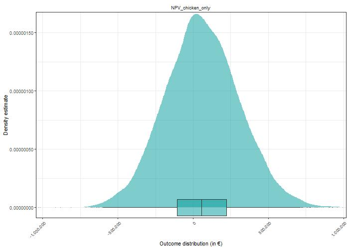

Figure 8.3: a ) Direct chicken revenue

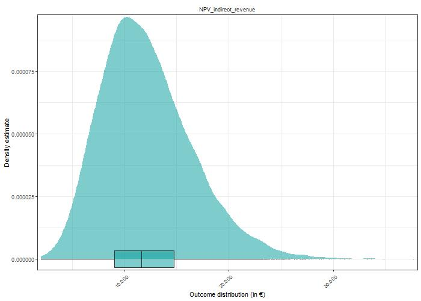

Figure 8.4: b ) Indirect chicken revenue

Figure 8.5: Figure 4) Outcome of Monte-Carlo-Simulation (n = 10,000) showing a) the direct revenue (direct benefit - direct cost) and b) indirect benefit (synergies - trade-off)

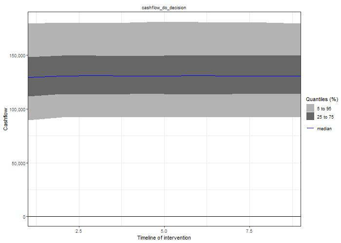

Figure 8.6: Figure 5: Cashflow of the decision to include chicken into an existing apple orchard

In the next step, the variables contribution to the NPV decision was calculated using the Projection to Latent Structures or also called Partial Least Square (PLS) method (Figure 6). Variables with positive contribution are shown in green/blue and with negative contribution in red. Variables with a Variable Importance in Projection (VIP) value greater than one include: egg_price, hourly_wage and feed_price. The VIP score of egg_price is roughly four times higher then of the next highest variable.

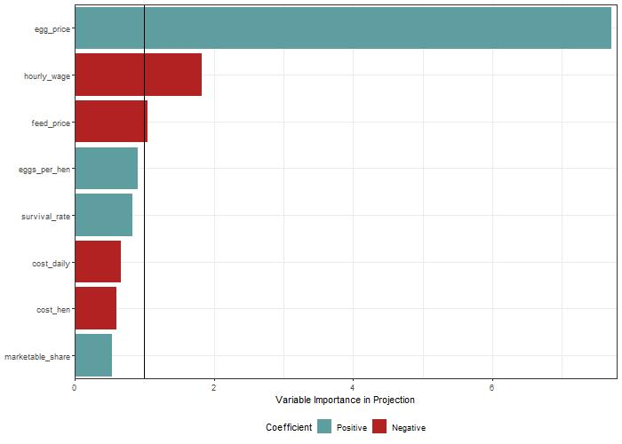

Figure 8.7: Figure 6: Result of the Projection to latent Structures (PLS) analysis on the decision to include chicken to the apple orchard. Bars denote the Variable Importance in the Projection (VIP). Green bars shows variables with positive and red bars variables with negative impact on the NPV

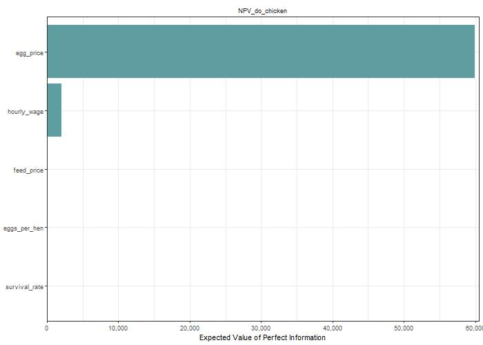

Figure 8.8: Figure 7: Expected value of information (EVPI) of the variables for the decision to include chicken to an apple orchard

# 9 Discussion

# 10 Conclusion

# References

Alpers, Anette. 2015. “Obstanlagen Als Ausläufe für Geflügel - Eine Eignungsanalyse.” *Kompetenzzentrum Ökolandbau Niedersachsen GmbH*.

Berg, C. 2002. “Health and Welfare in Organic Poultry Production.” *Acta Veterinaria Scandinavica* 43 (1): 1–9.

Bestman, Monique, and Judith Bikker-Ouwejan. 2020. “Predation in Organic and Free-Range Egg Production.” *Animals* 10 (2): 177.

Bestman, Monique, William de Jong, Jan-Paul Wagenaar, and Thari Weerts. 2018. “Presence of Avian Influenza Risk Birds in and Around Poultry Free-Range Areas in Relation to Range Vegetation and Openness of Surrounding Landscape.” *Agroforestry Systems* 92 (4): 1001–8.

Bestman, MWP, Approved John Hermansen, and Paul Burgess. 2017. “Lessons Learnt-Agroforestry for Organic and Free-Range Egg Production in the Netherlands.” *AGFORWARD Report Work-Package* 5.

Bestman, MWP, and Jan-Paul Wagenaar. 2003. “Farm Level Factors Associated with Feather Pecking in Organic Laying Hens.” *Livestock Production Science* 80 (1-2): 133–40.

Broom, Donald M. 1988. “The Scientific Assessment of Animal Welfare.” *Applied Animal Behaviour Science* 20 (1-2): 5–19.

Brownlow, MJC, SP Carruthers, and PT Dorward. 2000. “Alternatives to Grazing Livestock.” *Agroforestry in the UK, Forestry Commission Bulletin* 122: 58–70.

Dawkins, Marian Stamp, Paul A Cook, Mark J Whittingham, Katherine A Mansell, and Amy E Harper. 2003. “What Makes Free-Range Broiler Chickens Range? In Situ Measurement of Habitat Preference.” *Animal Behaviour* 66 (1): 151–60.

Do, Hoa, Eike Luedeling, and Cory Whitney. 2020. “Decision Analysis of Agroforestry Options Reveals Adoption Risks for Resource-Poor Farmers.” *Agronomy for Sustainable Development* 40: 1–12.

Hemery, GE. 2005. “A Novel Silvo-Poultry System.” *Quarterly Journal of Forestry* 99 (2): 131–33.

KTBL. 2010. “Kalkulationsanwendung Obstbau.” *Kuratorium für Technik Und Bauwesen in Der Landwirtschaft*. https://www.ktbl.de/webanwendungen/obstbau.

Luedeling, Eike, Lutz Goehring, Katja Schiffers, Cory Whitney, and Eduardo Fernandez. 2021. *decisionSupport: Quantitative Support of Decision Making Under Uncertainty*. https://cran.r-project.org/web/packages/decisionSupport/index.html.

Luedeling, Eike, and Keith Shepherd. 2016. “Decision-Focused Agricultural Research.” *Solutions* 7 (5): 46–54.

Pedersen, H Lindhard, A Olsen, K Horsted, M Korsgaard, B Pedersen, and others. 2004. “Combined Production of Broilers and Fruits.” In *Proc. XIth Ecofruit, Int. Conf. Cultivation Technique and Phytopathological Problems in Organic Fruit-Growing, Weinsberg, Ger*, 131–36.

Rojas, Gonzalo, Eduardo Fernandez, Cory Whitney, Eike Luedeling, and Italo F Cuneo. 2021. “Adapting Sweet Cherry Orchards to Extreme Weather Events - Decision Analysis in Support of Farmers’ Investments in Central Chile.” *Agricultural Systems* 187: 103031.

Smith, Jo, Bruce D Pearce, and Martin S Wolfe. 2013. “Reconciling Productivity with Protection of the Environment: Is Temperate Agroforestry the Answer?” *Renewable Agriculture and Food Systems* 28 (1): 80–92.

Timmermans, B. 2016. “Quality of Apple Trees and Apples in Poultry Free Range Areas.” In *3rd European Agroforestry Conference Montpellier, 23-25 May 2016*. EURAF.

Whitney, Cory W, Denis Lanzanova, Caroline Muchiri, Keith D Shepherd, Todd S Rosenstock, Michael Krawinkel, John RS Tabuti, and Eike Luedeling. 2018. “Probabilistic Decision Tools for Determining Impacts of Agricultural Development Policy on Household Nutrition.” *Earth’s Future* 6 (3): 359–72.

Yates, Christopher, Peter Dorward, Gabriel Hemery, and Paul Cook. 2007. “The Economic Viability and Potential of a Novel Poultry Agroforestry System.” *Agroforestry Systems* 69 (1): 13–28.